# Logistic Regression and Random Forest to Determine Credit Card Default

Travis Gubbe

June 27, 2026

In this session, I examine the Credit Card Clients data set found on the UCI Machine Learning Repository website to determine if a person will default on their credit card using logistic regression and random forest.

## About the Data Set

The data set can be found on the UCI Machine Learning Repository site at the following link: https://archive.ics.uci.edu/ml/datasets/default+of+credit+card+clients.

The data contains 24 variables and a total of 30,000 individual instances. The variables are:

- Default Payment (0 = No, 1 = Yes)
- Amount of Given Credit
- Gender (1 = Male, 2 = Female)
- Education (1 = Graduate School, 2 = University, 3 = High School, 4 = Other, 5 = Unknown)
- Marital Status (1 = Married, 2 = Single, 3 = Others)
- Age
- History of Past Payment from April 2005 to September 2005 where -2=no consumption, -1=pay duly, 0=the use of revolving credit, 1=payment delay for one month, 2=payment delay for two months, … 9=payment delay for nine months and above
- Amount of Bill Statement from April 2005 to September 2005
- Amount of Previous Payment April 2005 to September 2005

There is a separate variable for each past payment, bill statement, and previous payment from April to September.

## Exploratory Analysis

First, the data set is loaded into a data frame named “credit”. The data frame is also viewed to see the columns and class types.

```r
data <- read.csv("~/R datasets/Credit_Card.csv")
credit = subset(data, select = c("Limit_Bal", "Sex", "Education", "Marriage", "Age", "Pay_Sep",
                                 "Pay_Aug", "Pay_July", "Pay_June", "Pay_May", "Pay_April",
                                 "Bill_Amt_Sep", "Bill_Amt_Aug", "Bill_Amt_July",
                                 "Bill_Amt_June", "Bill_Amt_May", "Bill_Amt_April",
                                 "Pay_Amt_Sep", "Pay_Amt_Aug", "Pay_Amt_July","Pay_Amt_June",
                                 "Pay_Amt_May", "Pay_Amt_April", "Default"))
#Inspect the data frame
head(credit)
```

```
##   Limit_Bal Sex Education Marriage Age Pay_Sep Pay_Aug Pay_July Pay_June
## 1     20000   2         2        1  24       2       2       -1       -1
## 2    120000   2         2        2  26      -1       2        0        0
## 3     90000   2         2        2  34       0       0        0        0
## 4     50000   2         2        1  37       0       0        0        0
## 5     50000   1         2        1  57      -1       0       -1        0
## 6     50000   1         1        2  37       0       0        0        0
##   Pay_May Pay_April Bill_Amt_Sep Bill_Amt_Aug Bill_Amt_July Bill_Amt_June
## 1      -2        -2         3913         3102           689             0
## 2       0         2         2682         1725          2682          3272
## 3       0         0        29239        14027         13559         14331
## 4       0         0        46990        48233         49291         28314
## 5       0         0         8617         5670         35835         20940
## 6       0         0        64400        57069         57608         19394
##   Bill_Amt_May Bill_Amt_April Pay_Amt_Sep Pay_Amt_Aug Pay_Amt_July Pay_Amt_June
## 1            0              0           0         689            0            0
## 2         3455           3261           0        1000         1000         1000
## 3        14948          15549        1518        1500         1000         1000
## 4        28959          29547        2000        2019         1200         1100
## 5        19146          19131        2000       36681        10000         9000
## 6        19619          20024        2500        1815          657         1000
##   Pay_Amt_May Pay_Amt_April Default
## 1           0             0       1
## 2           0          2000       1
## 3        1000          5000       0
## 4        1069          1000       0
## 5         689           679       0
## 6        1000           800       0
```

```r
#Inspect the classes of the data frame
sapply(credit, class)
```

```
##      Limit_Bal            Sex      Education       Marriage            Age
##      "integer"      "integer"      "integer"      "integer"      "integer"
##        Pay_Sep        Pay_Aug       Pay_July       Pay_June        Pay_May
##      "integer"      "integer"      "integer"      "integer"      "integer"
##      Pay_April   Bill_Amt_Sep   Bill_Amt_Aug  Bill_Amt_July  Bill_Amt_June
##      "integer"      "integer"      "integer"      "integer"      "integer"
##   Bill_Amt_May Bill_Amt_April    Pay_Amt_Sep    Pay_Amt_Aug   Pay_Amt_July
##      "integer"      "integer"      "integer"      "integer"      "integer"
##   Pay_Amt_June    Pay_Amt_May  Pay_Amt_April        Default
##      "integer"      "integer"      "integer"      "integer"
```

```r
attach(credit)
```

Next, I want to see the amount of missing values and duplicates in the data frame.

```r
sum(is.na(credit))
```

```
## [1] 0
```

```r
duplicates <- credit%>%duplicated()
duplicates_amount <- duplicates%>%(table)
duplicates_amount
```

```
## .
## FALSE  TRUE
## 29965    35
```

Since there are 35 duplicates in the data, the data frame is filtered to remove the duplicates.

```r
credit <- credit%>%distinct()
#Displays how many duplicates are present in the updated data frame.
duplicates_counts_unique <- credit%>%duplicated()%>%table()
duplicates_counts_unique
```

```
## .
## FALSE
## 29965
```

Next, the factor variables are converted from their numeric values to their actual names. This is done on a copy of the credit data frame.

```r
credit1 <- data.frame(credit)
head(credit1)
```

```
##   Limit_Bal Sex Education Marriage Age Pay_Sep Pay_Aug Pay_July Pay_June
## 1     20000   2         2        1  24       2       2       -1       -1
## 2    120000   2         2        2  26      -1       2        0        0
## 3     90000   2         2        2  34       0       0        0        0
## 4     50000   2         2        1  37       0       0        0        0
## 5     50000   1         2        1  57      -1       0       -1        0
## 6     50000   1         1        2  37       0       0        0        0
##   Pay_May Pay_April Bill_Amt_Sep Bill_Amt_Aug Bill_Amt_July Bill_Amt_June
## 1      -2        -2         3913         3102           689             0
## 2       0         2         2682         1725          2682          3272
## 3       0         0        29239        14027         13559         14331
## 4       0         0        46990        48233         49291         28314
## 5       0         0         8617         5670         35835         20940
## 6       0         0        64400        57069         57608         19394
##   Bill_Amt_May Bill_Amt_April Pay_Amt_Sep Pay_Amt_Aug Pay_Amt_July Pay_Amt_June
## 1            0              0           0         689            0            0
## 2         3455           3261           0        1000         1000         1000
## 3        14948          15549        1518        1500         1000         1000
## 4        28959          29547        2000        2019         1200         1100
## 5        19146          19131        2000       36681        10000         9000
## 6        19619          20024        2500        1815          657         1000
##   Pay_Amt_May Pay_Amt_April Default
## 1           0             0       1
## 2           0          2000       1
## 3        1000          5000       0
## 4        1069          1000       0
## 5         689           679       0
## 6        1000           800       0
```

```r
#Rename factor variables to their appropriate settings
credit1$Sex[credit$Sex %in% "1"] = "Male"
credit1$Sex[credit$Sex %in% "2"] = "Female"

credit1$Education[credit$Education %in% "1"] = "Grad School"
credit1$Education[credit$Education %in% "2"] = "College"
credit1$Education[credit$Education %in% "3"] = "High School"
credit1$Education[credit$Education %in% "4"] = "Other"
credit1$Education[credit$Education %in% "5"] = "Unknown"

credit1$Marriage[credit$Marriage %in% "0"] = "Unknown"
credit1$Marriage[credit$Marriage %in% "1"] = "Married"
credit1$Marriage[credit$Marriage %in% "2"] = "Single"
credit1$Marriage[credit$Marriage %in% "3"] = "Other"

credit1$Default[credit$Default %in% "0"] = "No"
credit1$Default[credit$Default %in% "1"] = "Yes"
#See the change in the variable names
head(credit1)
```

```
##   Limit_Bal    Sex   Education Marriage Age Pay_Sep Pay_Aug Pay_July Pay_June
## 1     20000 Female     College  Married  24       2       2       -1       -1
## 2    120000 Female     College   Single  26      -1       2        0        0
## 3     90000 Female     College   Single  34       0       0        0        0
## 4     50000 Female     College  Married  37       0       0        0        0
## 5     50000   Male     College  Married  57      -1       0       -1        0
## 6     50000   Male Grad School   Single  37       0       0        0        0
##   Pay_May Pay_April Bill_Amt_Sep Bill_Amt_Aug Bill_Amt_July Bill_Amt_June
## 1      -2        -2         3913         3102           689             0
## 2       0         2         2682         1725          2682          3272
## 3       0         0        29239        14027         13559         14331
## 4       0         0        46990        48233         49291         28314
## 5       0         0         8617         5670         35835         20940
## 6       0         0        64400        57069         57608         19394
##   Bill_Amt_May Bill_Amt_April Pay_Amt_Sep Pay_Amt_Aug Pay_Amt_July Pay_Amt_June
## 1            0              0           0         689            0            0
## 2         3455           3261           0        1000         1000         1000
## 3        14948          15549        1518        1500         1000         1000
## 4        28959          29547        2000        2019         1200         1100
## 5        19146          19131        2000       36681        10000         9000
## 6        19619          20024        2500        1815          657         1000
##   Pay_Amt_May Pay_Amt_April Default
## 1           0             0     Yes
## 2           0          2000     Yes
## 3        1000          5000      No
## 4        1069          1000      No
## 5         689           679      No
## 6        1000           800      No
```

Next, exploratory tables are made to view the distribution of the data set.

### Exploratory Analysis

Next, bar plots and distribution tables are created to see the proportion of the variables. This is done to see if the data is normally distributed. If the data is not normally distributed, it’s advantageous to see how the data is skewed.

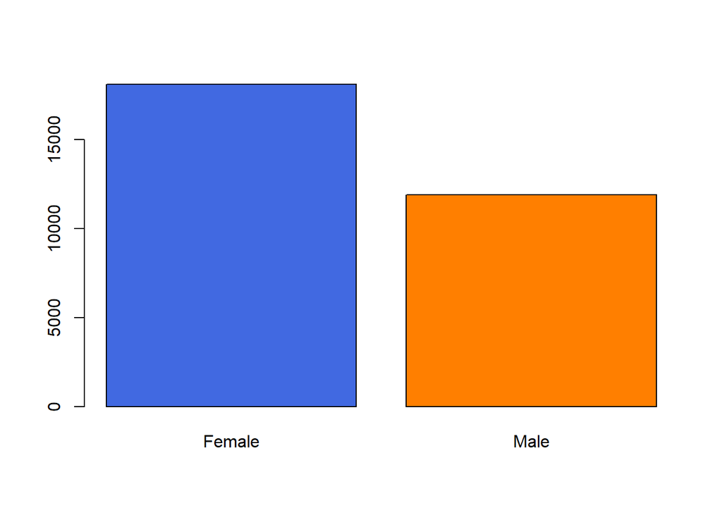

```r
#View the bar plots for the amount for each categorical variable
counts_Sex <- table(credit1$Sex)
barplot(counts_Sex, col = c("royalblue", "darkorange1"))
```

```r
#Basic table view of the amount of males and females
table(credit1$Sex)
```

```
##
## Female   Male
##  18091  11874
```

```r
#Proportion of each gender in table
prop.table(counts_Sex)
```

```
##
##    Female      Male
## 0.6037377 0.3962623
```

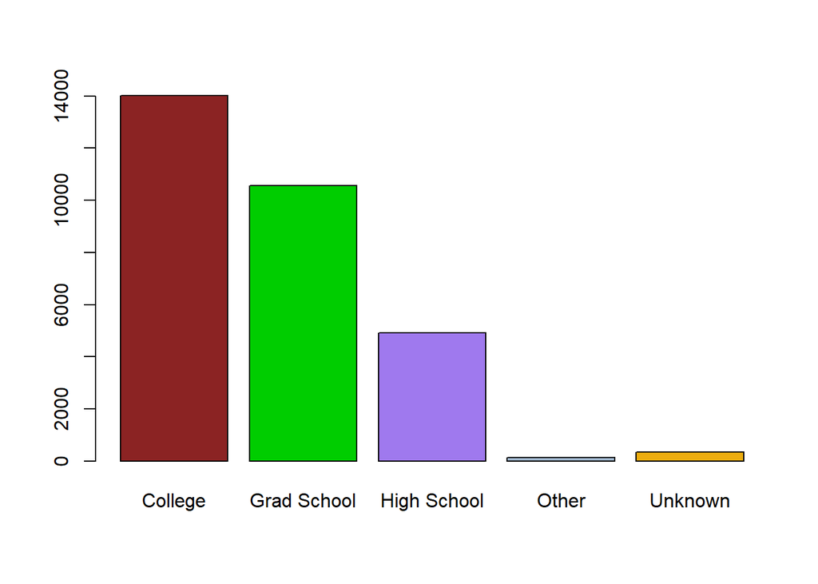

```r
counts_Education <- table(credit1$Education)
barplot(counts_Education, col = c("brown4", "green3", "mediumpurple2", "slategray3",
                                  "darkgoldenrod2"))
```

```r
table(credit1$Education)
```

```
##
##     College Grad School High School       Other     Unknown
##       14019       10563        4915         123         345
```

```r
#Proportion of each education level in table
prop.table(counts_Education)
```

```
##
##     College Grad School High School       Other     Unknown
## 0.467845820 0.352511263 0.164024695 0.004104789 0.011513432
```

```r
#Age groups divided into decades, then proportion table of each age group.
credit1$Age_Group <- cut(credit$Age,
                        breaks = c(20, 30, 40, 50, 60, 70, 80),
                        labels = c("20s", "30s", "40s", "50s", "60s", "70+"),
                        right = FALSE)

counts_Age <- table(credit1$Age_Group)
# Check distribution
prop.table(counts_Age)
```

```
##
##          20s          30s          40s          50s          60s          70+
## 0.3204738862 0.3746370766 0.2154513599 0.0781244786 0.0104788920 0.0008343067
```

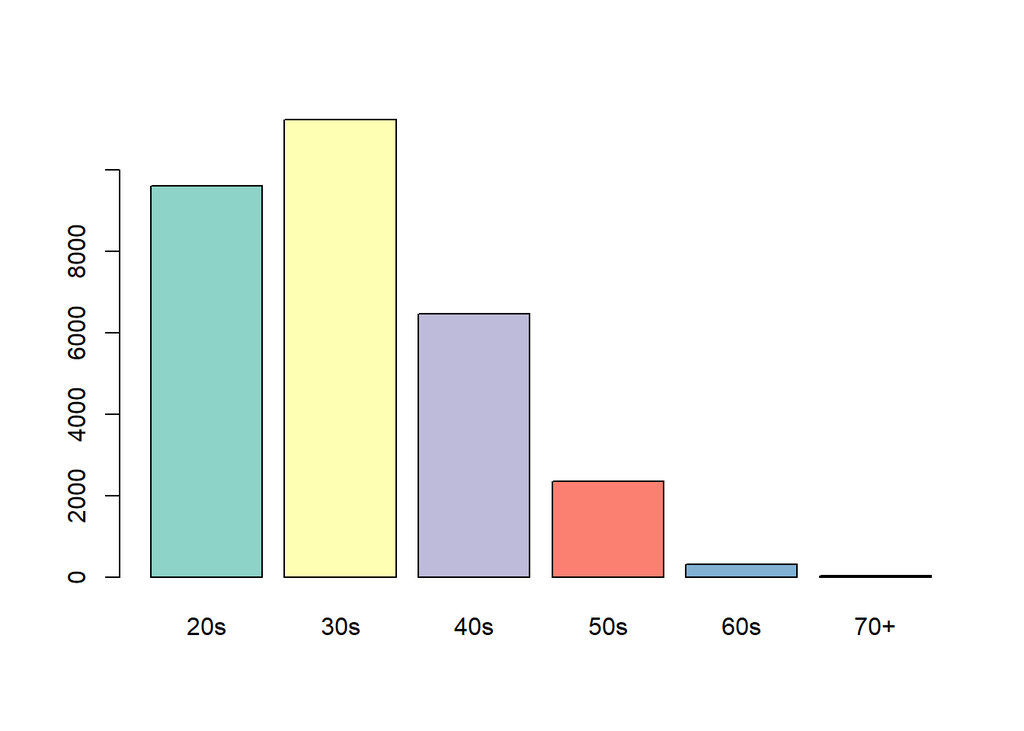

```r
#Bar plot of age groups with custom colors
colors <- brewer.pal(6, "Set3")
barplot(counts_Age, col = colors)
```

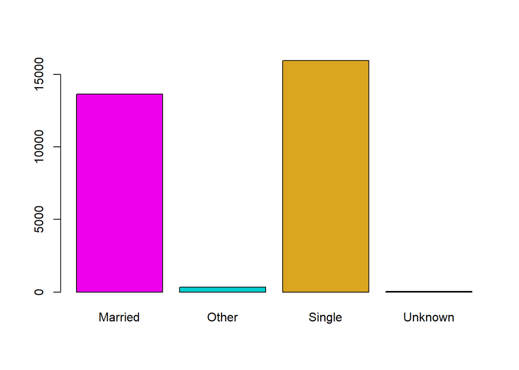

```r
#Counts for each marriage status.
counts_Marriage <- table(credit1$Marriage)
barplot(counts_Marriage, col = c("magenta2", "Cyan3", "goldenrod"))
```

```r
table(credit$Marriage)
```

```
##
##     0     1     2     3
##    54 13643 15945   323
```

```r
#Proportion of each marriage status in table
prop.table(counts_Marriage)
```

```
##
##     Married       Other      Single     Unknown
## 0.455297847 0.010779242 0.532120808 0.001802102
```

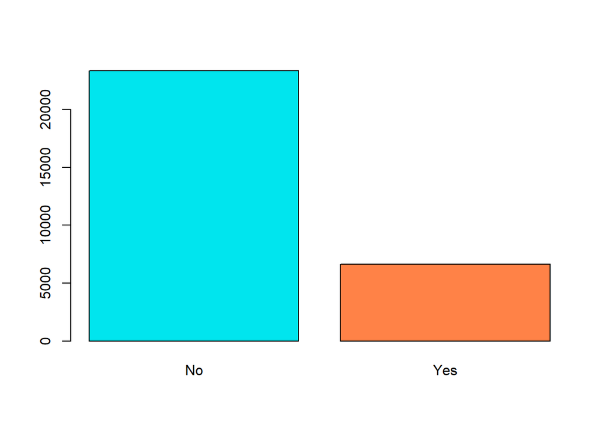

```r
counts_Default <- table(credit1$Default)
barplot(counts_Default, col = c("turquoise2", "sienna1"))
```

```r
table(credit$Default)
```

```
##
##     0     1
## 23335  6630
```

```r
prop.table(counts_Default)
```

```
##
##        No       Yes
## 0.7787419 0.2212581
```

```r
table.default_gender <- table(credit1$Default, credit$Sex)
prop.table(table.default_gender, 2)
```

```
##
##               1         2
##   No  0.7583797 0.7921066
##   Yes 0.2416203 0.2078934
```

```r
prop.table(table.default_gender, 1)
```

```
##
##              1        2
##   No  0.385901 0.614099
##   Yes 0.432730 0.567270
```

[figure not shown]

```r
barplot(table.default_gender, col = c("sienna1", "royalblue"), beside = T,
        names.arg = c("Female", "Male"))
legend("topright", legend = c("No", "Yes"), fill = c("sienna1", "royalblue"))
```

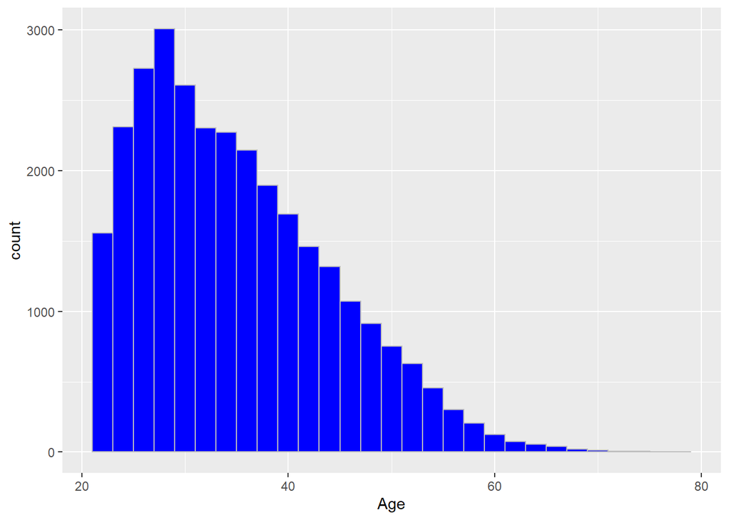

```r
ggplot(data = credit, aes(x = Age)) + geom_histogram(fill = "Blue", col = "Grey", bins = 30)
```

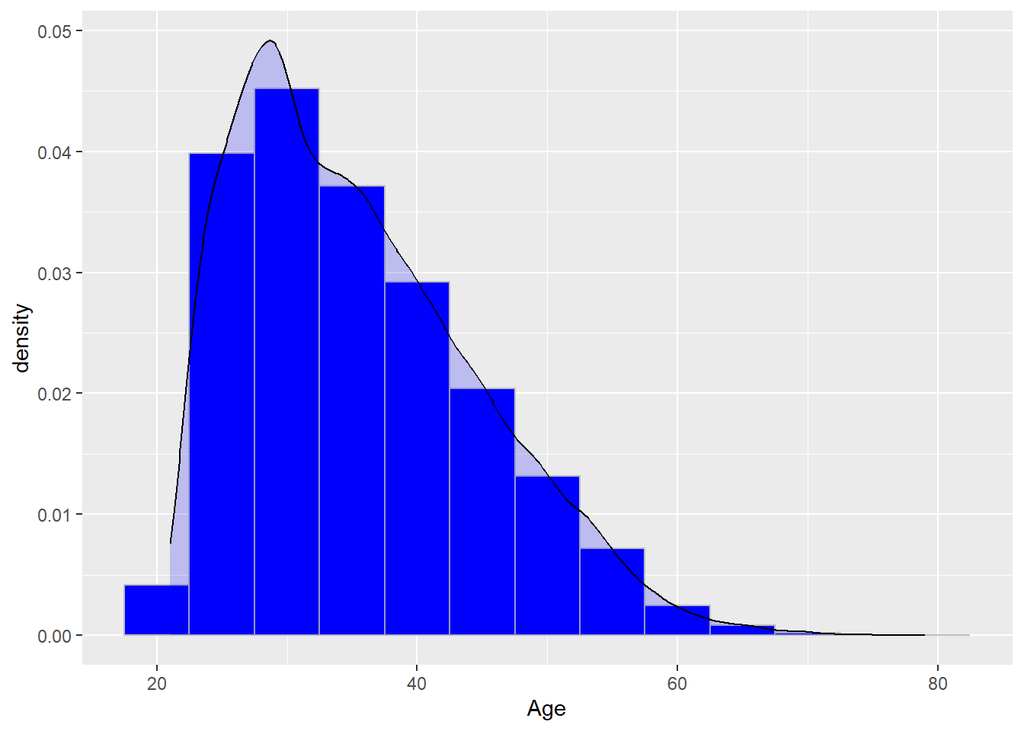

```r
ggplot(data = credit, aes(x = Age)) + geom_histogram(aes(y = ..density..), fill = "Blue", col = "Grey", binwidth = 5)+geom_density(alpha = 0.2, color = "black", fill = "blue")
```

```r
mean(credit1$Age)
```

```
## [1] 35.48797
```

Looking at the created charts and tables, the data has more females than males. In addition, the age group distribution is skewed to the right, meaning the data is represented by younger participants.

Another method for exploratory analysis is to investigate the correlation of the numeric variables. The correlation of numeric variables can help with model selection later on, as high correlation can indicate multicollinearity among variables, which can make it difficult for a model to separate and distinguish the importance of individual variables in the final model selection.

```r
eda_numeric_only <- credit1[, c("Limit_Bal", "Age",
                                "Bill_Amt_Sep", "Bill_Amt_Aug", "Bill_Amt_July", "Bill_Amt_June", "Bill_Amt_May",
                                "Bill_Amt_April", "Pay_Amt_Sep", "Pay_Amt_Aug", "Pay_Amt_July", "Pay_Amt_June",
                                "Pay_Amt_May", "Pay_Amt_April")]

# 2. Compute the Pearson correlation matrix safely
clean_eda_cor <- cor(eda_numeric_only, use = "complete.obs")

# 3. Print the perfectly aligned results rounded to 2 decimal places
print(round(clean_eda_cor, 2))
```

```
##                Limit_Bal  Age Bill_Amt_Sep Bill_Amt_Aug Bill_Amt_July
## Limit_Bal           1.00 0.14         0.29         0.28          0.28
## Age                 0.14 1.00         0.06         0.05          0.05
## Bill_Amt_Sep        0.29 0.06         1.00         0.95          0.89
## Bill_Amt_Aug        0.28 0.05         0.95         1.00          0.93
## Bill_Amt_July       0.28 0.05         0.89         0.93          1.00
## Bill_Amt_June       0.29 0.05         0.86         0.89          0.92
## Bill_Amt_May        0.30 0.05         0.83         0.86          0.88
## Bill_Amt_April      0.29 0.05         0.80         0.83          0.85
## Pay_Amt_Sep         0.20 0.03         0.14         0.28          0.24
## Pay_Amt_Aug         0.18 0.02         0.10         0.10          0.32
## Pay_Amt_July        0.21 0.03         0.16         0.15          0.13
## Pay_Amt_June        0.20 0.02         0.16         0.15          0.14
## Pay_Amt_May         0.22 0.02         0.17         0.16          0.18
## Pay_Amt_April       0.22 0.02         0.18         0.17          0.18
##                Bill_Amt_June Bill_Amt_May Bill_Amt_April Pay_Amt_Sep
## Limit_Bal               0.29         0.30           0.29        0.20
## Age                     0.05         0.05           0.05        0.03
## Bill_Amt_Sep            0.86         0.83           0.80        0.14
## Bill_Amt_Aug            0.89         0.86           0.83        0.28
## Bill_Amt_July           0.92         0.88           0.85        0.24
## Bill_Amt_June           1.00         0.94           0.90        0.23
## Bill_Amt_May            0.94         1.00           0.95        0.22
## Bill_Amt_April          0.90         0.95           1.00        0.20
## Pay_Amt_Sep             0.23         0.22           0.20        1.00
## Pay_Amt_Aug             0.21         0.18           0.17        0.29
## Pay_Amt_July            0.30         0.25           0.23        0.25
## Pay_Amt_June            0.13         0.29           0.25        0.20
## Pay_Amt_May             0.16         0.14           0.31        0.15
## Pay_Amt_April           0.18         0.16           0.12        0.19
##                Pay_Amt_Aug Pay_Amt_July Pay_Amt_June Pay_Amt_May Pay_Amt_April
## Limit_Bal             0.18         0.21         0.20        0.22          0.22
## Age                   0.02         0.03         0.02        0.02          0.02
## Bill_Amt_Sep          0.10         0.16         0.16        0.17          0.18
## Bill_Amt_Aug          0.10         0.15         0.15        0.16          0.17
## Bill_Amt_July         0.32         0.13         0.14        0.18          0.18
## Bill_Amt_June         0.21         0.30         0.13        0.16          0.18
## Bill_Amt_May          0.18         0.25         0.29        0.14          0.16
## Bill_Amt_April        0.17         0.23         0.25        0.31          0.12
## Pay_Amt_Sep           0.29         0.25         0.20        0.15          0.19
## Pay_Amt_Aug           1.00         0.24         0.18        0.18          0.16
## Pay_Amt_July          0.24         1.00         0.22        0.16          0.16
## Pay_Amt_June          0.18         0.22         1.00        0.15          0.16
## Pay_Amt_May           0.18         0.16         0.15        1.00          0.15
## Pay_Amt_April         0.16         0.16         0.16        0.15          1.00
```

From the results, there are a few instances of high correlation between various numeric variables, particularly among variables with similar measurements (Bill_Amt_April and Bill_Amt_May). This will play a factor later in the analysis, particularly for the logistic regression model’s regularization techniques.

### Train and Test Sets

Before creating prediction models, training and testing data sets are created. A training data set is a subset of examples used to train the model, while the testing data set is a subset used to test the training model.

```r
#Initializes number generator.
set.seed(123)
#New sample created for the training and testing data sets. The data is split with 75% in training and 25% in testing.
sample_split <- sample(c(TRUE, FALSE), nrow(credit), replace = TRUE, prob = c(0.75, 0.25))
train_set <- credit[sample_split, ]
test_set <- credit[!sample_split, ]

X_train <- model.matrix(Default ~ ., data = train_set)[, -1]
y_train <- as.numeric(train_set$Default)

# 2. Prepare the TESTING data matrices
X_test  <- model.matrix(Default ~ ., data = test_set)[, -1]
y_test  <- as.numeric(test_set$Default)
```

## Logistic Regression

First, logistic regression is done to find the probability of default for an individual. Logistic regression models the probability that a response variable (Y) belongs to a particular category. This method uses maximum likelihood to fit the model in the range between 0 and 1.

Logistic regression is a classification method great for a yes/no response. A number closer to 1 represents “Yes”, while a number closer to 0 represents “No”.

Before the creation of the model, An elastic net logistic regression model is first run as a means of feature selection and to prevent overfitting in the model. Elastic net is a hybrid version of the LASSO and ridge regularization methods, performing both coefficient shrinkage and feature selection which is appropriate in this case due to the high correlation among multiple variables. The elastic net has more flexibility than the LASSO regularization and is more robust than the Ridge regularization, selecting and dropping entire an entire group of correlated groups.

From the glmnet package, any alpha value between 0 and 1 is classified as elastic net. A for loop was created to determine the best alpha value among when separating by between three alpha values (0.2, 0.5, and 0.8).

```r
library(glmnet)
#Elastic net for the data set
#Determine best alpha value
alphas <- c(0.2, 0.5, 0.8)
for (a in alphas) {
  set.seed(123)
  cv_model <- cv.glmnet(X_train, y_train, family = "binomial", alpha = a)
  cat("Alpha:", a, " Minimum Deviance:", min(cv_model$cvm), "\n")
}
```

```
## Alpha: 0.2  Minimum Deviance: 0.9382583
## Alpha: 0.5  Minimum Deviance: 0.9382775
## Alpha: 0.8  Minimum Deviance: 0.938284
```

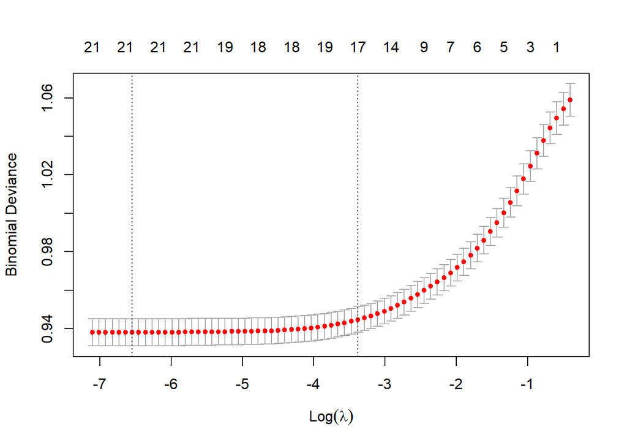

```r
cv_en <- cv.glmnet(X_train, y_train, family = "binomial", alpha = 0.2, standardize = TRUE)

plot(cv_en)
```

```r
en_coefs <- coef(cv_en, s = "lambda.1se")
print(en_coefs)
```

```
## 24 x 1 sparse Matrix of class "dgCMatrix"
##                           s0
## (Intercept)    -1.063969e+00
## Limit_Bal      -6.226294e-07
## Sex             .
## Education      -3.876596e-03
## Marriage       -9.217191e-02
## Age             2.371693e-03
## Pay_Sep         4.390245e-01
## Pay_Aug         1.055434e-01
## Pay_July        5.965425e-02
## Pay_June        2.679787e-02
## Pay_May         3.079567e-02
## Pay_April       1.334030e-02
## Bill_Amt_Sep   -7.911601e-07
## Bill_Amt_Aug   -1.380020e-07
## Bill_Amt_July   .
## Bill_Amt_June   .
## Bill_Amt_May    .
## Bill_Amt_April  .
## Pay_Amt_Sep    -4.444265e-06
## Pay_Amt_Aug    -2.242520e-06
## Pay_Amt_July   -6.183747e-07
## Pay_Amt_June   -1.317573e-06
## Pay_Amt_May    -4.905997e-07
## Pay_Amt_April   .
```

```r
fit_glm_cv <- glm(Default ~ Limit_Bal+Marriage+Age+Pay_Sep+Pay_Aug+Pay_July+
                  Pay_June+Bill_Amt_Sep+Pay_Amt_Sep+Pay_Amt_Aug+
                  Pay_Amt_July+Pay_Amt_June+Pay_Amt_May,
                  data = train_set, family = binomial())

summary(fit_glm_cv)
```

```
##
## Call:
## glm(formula = Default ~ Limit_Bal + Marriage + Age + Pay_Sep +
##     Pay_Aug + Pay_July + Pay_June + Bill_Amt_Sep + Pay_Amt_Sep +
##     Pay_Amt_Aug + Pay_Amt_July + Pay_Amt_June + Pay_Amt_May,
##     family = binomial(), data = train_set)
##
## Coefficients:
##                Estimate Std. Error z value Pr(>|z|)
## (Intercept)  -1.039e+00  1.095e-01  -9.491  < 2e-16 ***
## Limit_Bal    -5.282e-07  1.726e-07  -3.060 0.002211 **
## Marriage     -1.704e-01  3.604e-02  -4.728 2.27e-06 ***
## Age           6.365e-03  1.987e-03   3.204 0.001358 **
## Pay_Sep       5.768e-01  2.041e-02  28.262  < 2e-16 ***
## Pay_Aug       8.705e-02  2.309e-02   3.770 0.000164 ***
## Pay_July      6.713e-02  2.560e-02   2.622 0.008735 **
## Pay_June      6.018e-02  2.269e-02   2.652 0.008003 **
## Bill_Amt_Sep -1.485e-06  3.024e-07  -4.912 9.03e-07 ***
## Pay_Amt_Sep  -1.044e-05  2.329e-06  -4.480 7.46e-06 ***
## Pay_Amt_Aug  -1.004e-05  2.204e-06  -4.553 5.28e-06 ***
## Pay_Amt_July -2.328e-06  1.672e-06  -1.393 0.163708
## Pay_Amt_June -4.033e-06  1.760e-06  -2.291 0.021966 *
## Pay_Amt_May  -2.386e-06  1.581e-06  -1.509 0.131195
## ---
## Signif. codes:  0 '***' 0.001 '**' 0.01 '*' 0.05 '.' 0.1 ' ' 1
##
## (Dispersion parameter for binomial family taken to be 1)
##
##     Null deviance: 23800  on 22476  degrees of freedom
## Residual deviance: 21069  on 22463  degrees of freedom
## AIC: 21097
##
## Number of Fisher Scoring iterations: 6
```

```r
stepAIC(fit_glm_cv)
```

```
## Start:  AIC=21097.12
## Default ~ Limit_Bal + Marriage + Age + Pay_Sep + Pay_Aug + Pay_July +
##     Pay_June + Bill_Amt_Sep + Pay_Amt_Sep + Pay_Amt_Aug + Pay_Amt_July +
##     Pay_Amt_June + Pay_Amt_May
##
##                Df Deviance   AIC
## <none>               21069 21097
## - Pay_Amt_July  1    21071 21097
## - Pay_Amt_May   1    21072 21098
## - Pay_Amt_June  1    21075 21101
## - Pay_July      1    21076 21102
## - Pay_June      1    21076 21102
## - Limit_Bal     1    21079 21105
## - Age           1    21079 21105
## - Pay_Aug       1    21083 21109
## - Marriage      1    21092 21118
## - Bill_Amt_Sep  1    21094 21120
## - Pay_Amt_Sep   1    21097 21123
## - Pay_Amt_Aug   1    21099 21125
## - Pay_Sep       1    21860 21886
```

```
##
## Call:  glm(formula = Default ~ Limit_Bal + Marriage + Age + Pay_Sep +
##     Pay_Aug + Pay_July + Pay_June + Bill_Amt_Sep + Pay_Amt_Sep +
##     Pay_Amt_Aug + Pay_Amt_July + Pay_Amt_June + Pay_Amt_May,
##     family = binomial(), data = train_set)
##
## Coefficients:
##  (Intercept)     Limit_Bal      Marriage           Age       Pay_Sep
##   -1.039e+00    -5.282e-07    -1.704e-01     6.365e-03     5.768e-01
##      Pay_Aug      Pay_July      Pay_June  Bill_Amt_Sep   Pay_Amt_Sep
##    8.705e-02     6.713e-02     6.018e-02    -1.485e-06    -1.044e-05
##  Pay_Amt_Aug  Pay_Amt_July  Pay_Amt_June   Pay_Amt_May
##   -1.004e-05    -2.328e-06    -4.033e-06    -2.386e-06
##
## Degrees of Freedom: 22476 Total (i.e. Null);  22463 Residual
## Null Deviance:       23800
## Residual Deviance: 21070     AIC: 21100
```

```r
#VIF of the 2nd logistic regression model. VIF scores appear good.
vif(fit_glm_cv)
```

```
##    Limit_Bal     Marriage          Age      Pay_Sep      Pay_Aug     Pay_July
##     1.407081     1.207696     1.210552     1.514391     2.605634     3.202421
##     Pay_June Bill_Amt_Sep  Pay_Amt_Sep  Pay_Amt_Aug Pay_Amt_July Pay_Amt_June
##     2.425439     1.354999     1.161687     1.149575     1.096311     1.079075
##  Pay_Amt_May
##     1.082014
```

```r
fit_glm_cv2 <- glm(Default ~ Limit_Bal+Marriage+Age+Pay_Sep+Pay_Aug+Pay_July+
                  Pay_June+Bill_Amt_Sep+Bill_Amt_June+Pay_Amt_Sep+Pay_Amt_Aug+Pay_Amt_June,
                  data = train_set, family = binomial())

summary(fit_glm_cv2)
```

```
##
## Call:
## glm(formula = Default ~ Limit_Bal + Marriage + Age + Pay_Sep +
##     Pay_Aug + Pay_July + Pay_June + Bill_Amt_Sep + Bill_Amt_June +
##     Pay_Amt_Sep + Pay_Amt_Aug + Pay_Amt_June, family = binomial(),
##     data = train_set)
##
## Coefficients:
##                 Estimate Std. Error z value Pr(>|z|)
## (Intercept)   -1.034e+00  1.095e-01  -9.443  < 2e-16 ***
## Limit_Bal     -6.294e-07  1.721e-07  -3.657 0.000256 ***
## Marriage      -1.719e-01  3.604e-02  -4.769 1.85e-06 ***
## Age            6.377e-03  1.987e-03   3.209 0.001334 **
## Pay_Sep        5.757e-01  2.041e-02  28.205  < 2e-16 ***
## Pay_Aug        8.735e-02  2.309e-02   3.782 0.000155 ***
## Pay_July       6.360e-02  2.563e-02   2.482 0.013064 *
## Pay_June       5.611e-02  2.279e-02   2.462 0.013812 *
## Bill_Amt_Sep  -3.087e-06  6.015e-07  -5.132 2.87e-07 ***
## Bill_Amt_June  2.045e-06  6.969e-07   2.934 0.003342 **
## Pay_Amt_Sep   -1.188e-05  2.363e-06  -5.026 5.01e-07 ***
## Pay_Amt_Aug   -1.169e-05  2.269e-06  -5.150 2.61e-07 ***
## Pay_Amt_June  -4.274e-06  1.797e-06  -2.379 0.017372 *
## ---
## Signif. codes:  0 '***' 0.001 '**' 0.01 '*' 0.05 '.' 0.1 ' ' 1
##
## (Dispersion parameter for binomial family taken to be 1)
##
##     Null deviance: 23800  on 22476  degrees of freedom
## Residual deviance: 21065  on 22464  degrees of freedom
## AIC: 21091
##
## Number of Fisher Scoring iterations: 6
```

```r
stepAIC(fit_glm_cv2)
```

```
## Start:  AIC=21091.29
## Default ~ Limit_Bal + Marriage + Age + Pay_Sep + Pay_Aug + Pay_July +
##     Pay_June + Bill_Amt_Sep + Bill_Amt_June + Pay_Amt_Sep + Pay_Amt_Aug +
##     Pay_Amt_June
##
##                 Df Deviance   AIC
## <none>                21065 21091
## - Pay_June       1    21071 21095
## - Pay_July       1    21071 21095
## - Pay_Amt_June   1    21072 21096
## - Bill_Amt_June  1    21074 21098
## - Age            1    21076 21100
## - Limit_Bal      1    21079 21103
## - Pay_Aug        1    21080 21104
## - Marriage       1    21088 21112
## - Bill_Amt_Sep   1    21093 21117
## - Pay_Amt_Sep    1    21101 21125
## - Pay_Amt_Aug    1    21104 21128
## - Pay_Sep        1    21853 21877
```

```
##
## Call:  glm(formula = Default ~ Limit_Bal + Marriage + Age + Pay_Sep +
##     Pay_Aug + Pay_July + Pay_June + Bill_Amt_Sep + Bill_Amt_June +
##     Pay_Amt_Sep + Pay_Amt_Aug + Pay_Amt_June, family = binomial(),
##     data = train_set)
##
## Coefficients:
##   (Intercept)      Limit_Bal       Marriage            Age        Pay_Sep
##    -1.034e+00     -6.294e-07     -1.719e-01      6.377e-03      5.757e-01
##       Pay_Aug       Pay_July       Pay_June   Bill_Amt_Sep  Bill_Amt_June
##     8.735e-02      6.360e-02      5.611e-02     -3.087e-06      2.045e-06
##   Pay_Amt_Sep    Pay_Amt_Aug   Pay_Amt_June
##    -1.187e-05     -1.169e-05     -4.274e-06
##
## Degrees of Freedom: 22476 Total (i.e. Null);  22464 Residual
## Null Deviance:       23800
## Residual Deviance: 21070     AIC: 21090
```

```r
#VIF of the 2nd logistic regression model. VIF scores appear good.
vif(fit_glm_cv2)
```

```
##     Limit_Bal      Marriage           Age       Pay_Sep       Pay_Aug
##      1.399953      1.207157      1.211042      1.518304      2.610328
##      Pay_July      Pay_June  Bill_Amt_Sep Bill_Amt_June   Pay_Amt_Sep
##      3.216057      2.448008      5.355772      5.728086      1.173155
##   Pay_Amt_Aug  Pay_Amt_June
##      1.186303      1.075627
```

```r
#Elastic net logistic regression model - removed bill_amt_aug (high VIF)
#Removed pay_june and pay_may since they were not statistically significiant
fit_glm_cv3 <- glm(Default ~ Limit_Bal+Education+Marriage+Age+Pay_Sep+Pay_Aug+Pay_July+
                  Pay_May+Bill_Amt_Sep+Pay_Amt_Sep+Pay_Amt_Aug
                  +Pay_Amt_July+Pay_Amt_June,
                  data = train_set, family = binomial())

summary(fit_glm_cv3)
```

```
##
## Call:
## glm(formula = Default ~ Limit_Bal + Education + Marriage + Age +
##     Pay_Sep + Pay_Aug + Pay_July + Pay_May + Bill_Amt_Sep + Pay_Amt_Sep +
##     Pay_Amt_Aug + Pay_Amt_July + Pay_Amt_June, family = binomial(),
##     data = train_set)
##
## Coefficients:
##                Estimate Std. Error z value Pr(>|z|)
## (Intercept)  -8.290e-01  1.182e-01  -7.012 2.34e-12 ***
## Limit_Bal    -7.376e-07  1.777e-07  -4.152 3.30e-05 ***
## Education    -1.141e-01  2.412e-02  -4.732 2.22e-06 ***
## Marriage     -1.891e-01  3.633e-02  -5.204 1.95e-07 ***
## Age           8.102e-03  2.023e-03   4.006 6.18e-05 ***
## Pay_Sep       5.768e-01  2.038e-02  28.299  < 2e-16 ***
## Pay_Aug       8.320e-02  2.318e-02   3.589 0.000332 ***
## Pay_July      7.434e-02  2.311e-02   3.217 0.001294 **
## Pay_May       6.916e-02  2.018e-02   3.428 0.000609 ***
## Bill_Amt_Sep -1.468e-06  3.020e-07  -4.861 1.17e-06 ***
## Pay_Amt_Sep  -1.063e-05  2.346e-06  -4.530 5.89e-06 ***
## Pay_Amt_Aug  -9.974e-06  2.186e-06  -4.564 5.02e-06 ***
## Pay_Amt_July -3.254e-06  1.729e-06  -1.882 0.059821 .
## Pay_Amt_June -3.922e-06  1.762e-06  -2.226 0.026002 *
## ---
## Signif. codes:  0 '***' 0.001 '**' 0.01 '*' 0.05 '.' 0.1 ' ' 1
##
## (Dispersion parameter for binomial family taken to be 1)
##
##     Null deviance: 23800  on 22476  degrees of freedom
## Residual deviance: 21044  on 22463  degrees of freedom
## AIC: 21072
##
## Number of Fisher Scoring iterations: 6
```

```r
stepAIC(fit_glm_cv3)
```

```
## Start:  AIC=21072.31
## Default ~ Limit_Bal + Education + Marriage + Age + Pay_Sep +
##     Pay_Aug + Pay_July + Pay_May + Bill_Amt_Sep + Pay_Amt_Sep +
##     Pay_Amt_Aug + Pay_Amt_July + Pay_Amt_June
##
##                Df Deviance   AIC
## <none>               21044 21072
## - Pay_Amt_July  1    21048 21074
## - Pay_Amt_June  1    21050 21076
## - Pay_July      1    21055 21081
## - Pay_May       1    21056 21082
## - Pay_Aug       1    21057 21083
## - Age           1    21060 21086
## - Limit_Bal     1    21062 21088
## - Education     1    21067 21093
## - Bill_Amt_Sep  1    21069 21095
## - Marriage      1    21072 21098
## - Pay_Amt_Sep   1    21073 21099
## - Pay_Amt_Aug   1    21074 21100
## - Pay_Sep       1    21838 21864
```

```
##
## Call:  glm(formula = Default ~ Limit_Bal + Education + Marriage + Age +
##     Pay_Sep + Pay_Aug + Pay_July + Pay_May + Bill_Amt_Sep + Pay_Amt_Sep +
##     Pay_Amt_Aug + Pay_Amt_July + Pay_Amt_June, family = binomial(),
##     data = train_set)
##
## Coefficients:
##  (Intercept)     Limit_Bal     Education      Marriage           Age
##   -8.290e-01    -7.376e-07    -1.141e-01    -1.891e-01     8.102e-03
##      Pay_Sep       Pay_Aug      Pay_July       Pay_May  Bill_Amt_Sep
##    5.768e-01     8.320e-02     7.434e-02     6.916e-02    -1.468e-06
##  Pay_Amt_Sep   Pay_Amt_Aug  Pay_Amt_July  Pay_Amt_June
##   -1.063e-05    -9.974e-06    -3.254e-06    -3.922e-06
##
## Degrees of Freedom: 22476 Total (i.e. Null);  22463 Residual
## Null Deviance:       23800
## Residual Deviance: 21040     AIC: 21070
```

```r
#VIF of the 3rd logistic regression model. VIF scores appear good.
vif(fit_glm_cv3)
```

```
##    Limit_Bal    Education     Marriage          Age      Pay_Sep      Pay_Aug
##     1.483357     1.135733     1.223487     1.251707     1.509065     2.626893
##     Pay_July      Pay_May Bill_Amt_Sep  Pay_Amt_Sep  Pay_Amt_Aug Pay_Amt_July
##     2.602541     1.817958     1.347766     1.162570     1.129421     1.097237
## Pay_Amt_June
##     1.080306
```

Four variables are discarded due to either statistical insignificance in the model or a high VIF value, indicating high multicollinearity between multiple variables, leading to 13 variables being kept.

```r
pred_probs <- predict.glm(fit_glm_cv3, newdata = test_set, type = "response")
#Displays the predictions for a few values.
head(pred_probs)
```

```
##         2         4         5         8        11        16
## 0.1487036 0.2493531 0.1256277 0.1809134 0.2116167 0.2801776
```

```r
#Sorts predictions into their respective class (0 or 1) depending on their value.
pred <- ifelse(pred_probs<0.5, 0,1)
#Creates and displays the confusion matrix table based on the actual and predicted values.
confusion_table <- table(test_set$Default, pred)
confusion_table
```

```
##    pred
##        0    1
##   0 5713  135
##   1 1243  397
```

```r
#Creates the confusion matrix statistics for the logistic regression model.
cm_log <- confusionMatrix(confusion_table, positive = '1', mode = "everything")
#Saves the accuracy, precision, and recall values.
log_accuracy = accuracy(test_set$Default, pred)
log_precision = cm_log$byClass['Precision']
log_recall = cm_log$byClass['Recall']
log_pos_precision = cm_log$byClass['Neg Pred Value']
#Prints the accuracy, precision, and recall values.
print(paste("Accuracy: ", round(log_accuracy,3)))
```

```
## [1] "Accuracy:  0.816"
```

```r
print(paste("Precision: ", round(log_precision,3)))
```

```
## [1] "Precision:  0.242"
```

```r
print(paste("Recall: ", round(log_recall,3)))
```

```
## [1] "Recall:  0.746"
```

```r
print(paste("Default Precision: ", round(log_pos_precision,3)))
```

```
## [1] "Default Precision:  0.977"
```

Once the model was run, the accuracy, precision, and recall were found for the prediction model. Accuracy describes how often the model is correct in its overall prediction. Precision identifies how often the model identifies those who default on their credit card out of all who do so, while recall identifies how often the model correctly identifies those who default on their credit card.Another way of describing precision and recall is precision is a measure of quality, while recall is a measure of quantity.